# 20220906_Bipartite_example

2022-09-07

## Instructions

1. Reads in a standard bipartite dataset (Southern women?)
2. Reads in/constructs some people and even covariates (these could be created artificially if they do not come with the dataset)
3. Formats data in the form that statnet wants it (in particular, print out the dimensions of the affiliation matrix - rectangular? - and any other meta information available; are ties directed or not?)
4. Specifies a reasonable bipartite ERGM (check the ERGM book but a good model would require an alternating 4-path statistic and possibly some degree-based statistics)
5. Runs the estimation
6. Prints output and checks convergence

### Reading in data

Using the ‘latentnet’ package which has the dataset in it.

The dataset follows 18 women over a 9-month period where they all met each other across 14 informal social events. The data records which women met for which events.

```r
# reading packages
library(latentnet)
library(here)
```

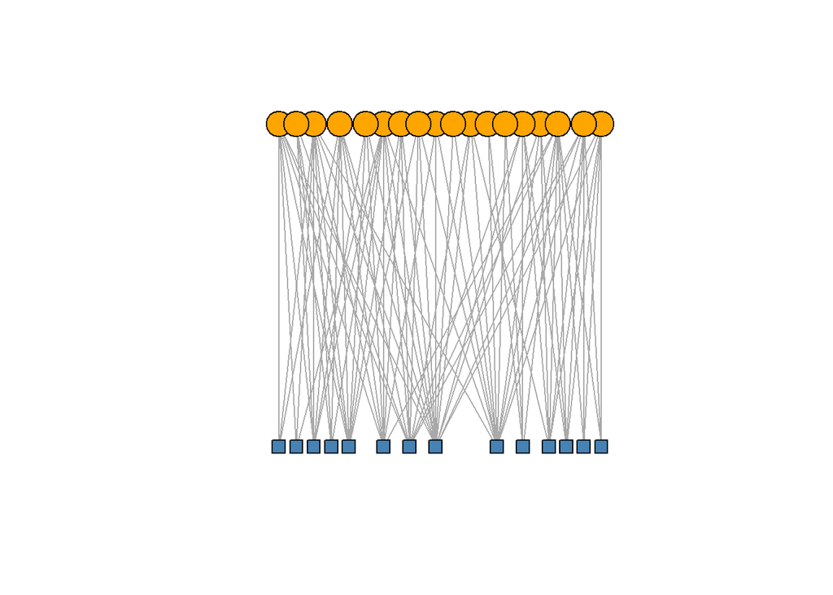

```r
library(igraph)
# read in the data
data(davis)

# plot it
adjmat = as.matrix(davis)
plotbip = graph_from_incidence_matrix(adjmat)

# set node type and colour
V(plotbip)$color <- c("orange", "steel blue")[V(plotbip)$type+1]
V(plotbip)$shape <- c("circle", "square")[V(plotbip)$type+1]
V(plotbip)$label <- ""
V(plotbip)$label.cex=.4
V(plotbip)$label.font=2



# and plot it
plot(plotbip, vertex.label.color="white", vertex.size=(2-V(plotbip)$type)*8, layout = layout_as_bipartite)
```

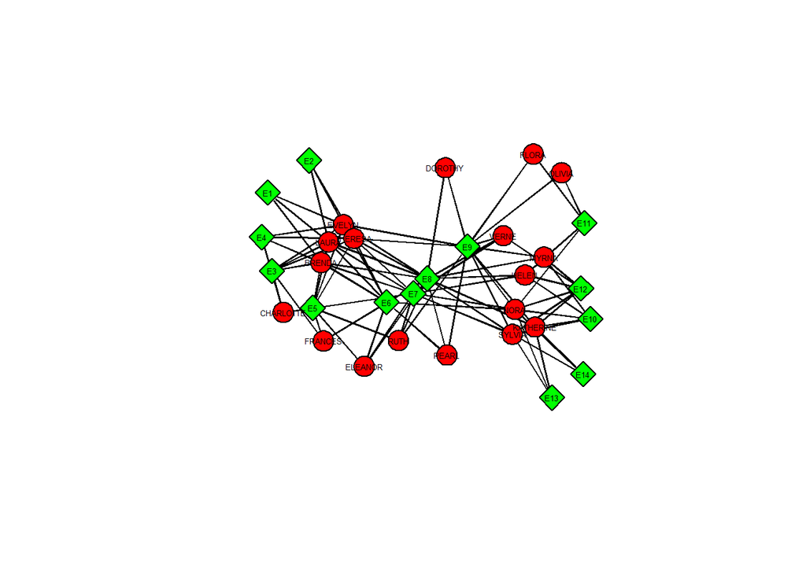

```r
# without igraph
plot(davis,
     displaylabels=TRUE,
     vertex.col = c(rep("Red", 18), rep("Green", 14)),
     vertex.sides = 4*c(rep(10, 18), rep(1, 14)),
     vertex.cex = c(rep(3, 18), rep(3, 14)),
     label.cex = 0.4,
     label.pos = 5)
```

### Generating attributes and formatting

```r
# fix seed
set.seed(420)

# randomly generating binary attributes for the people and events
peopleAtt = sample(c(0,1), 18, replace = TRUE)
eventAtt = sample(c(0,1), 14, replace = TRUE)

# set these attributes

# for women
network::set.vertex.attribute(x = davis,
                              attrname = "randAttPeople",
                              value = peopleAtt,
                              v = 1:18)

# for events
network::set.vertex.attribute(x = davis,
                              attrname = "randAttEvent",
                              value = eventAtt,
                              v = 19:32)
```

### Brief inspection and ergm time

```r
# Obtain women's names from network using %v% operator
names <- (davis %v% "vertex.names")[1:18]

# Create list where each item is an "edge"; look at first 5 of them
apply(adjmat, 2, function(event) names[event==1])[1:5]
```

```
## $E1
## [1] "EVELYN" "LAURA"  "BRENDA"
##
## $E2
## [1] "EVELYN"  "LAURA"   "THERESA"
##
## $E3
## [1] "EVELYN"    "LAURA"     "THERESA"   "BRENDA"    "CHARLOTTE" "FRANCES"
##
## $E4
## [1] "EVELYN"    "THERESA"   "BRENDA"    "CHARLOTTE"
##
## $E5
## [1] "EVELYN"    "LAURA"     "THERESA"   "BRENDA"    "CHARLOTTE" "FRANCES"
## [7] "ELEANOR"   "RUTH"
```

```r
# summary with an ergm formula reports the network's observed statistics
# represents the degree for each woman
summary(davis ~ sociality(nodes = 1:18))
```

```
##  sociality1  sociality2  sociality3  sociality4  sociality5  sociality6
##           8           7           8           7           4           4
##  sociality7  sociality8  sociality9 sociality10 sociality11 sociality12
##           4           3           4           4           4           6
## sociality13 sociality14 sociality15 sociality16 sociality17 sociality18
##           7           8           5           2           2           2
```

```r
## Commented out sociality
# # ergm
# fit1 <- ergm(davis ~ sociality(nodes = 1:18) + b2star(3))
#
# summary(fit1)
#
# # with a nodal covariate
# fit2 <- ergm(davis ~ b2star(3) + b2factor("randAttEvent") + sociality(nodes = 1:18))
#
# summary(fit2)

# with multipe nodal covariates?
fit3 <- ergm(davis ~ b2star(3) + b2factor("randAttEvent") + b1factor("randAttPeople"))
```

```
## Starting maximum pseudolikelihood estimation (MPLE):
```

```
## Evaluating the predictor and response matrix.
```

```
## Maximizing the pseudolikelihood.
```

```
## Finished MPLE.
```

```
## Starting Monte Carlo maximum likelihood estimation (MCMLE):
```

```
## Iteration 1 of at most 60:
```

```
## Optimizing with step length 1.0000.
```

```
## The log-likelihood improved by 2.5662.
```

```
## Estimating equations are not within tolerance region.
```

```
## Iteration 2 of at most 60:
```

```
## Optimizing with step length 1.0000.
```

```
## The log-likelihood improved by 0.8196.
```

```
## Estimating equations are not within tolerance region.
```

```
## Iteration 3 of at most 60:
```

```
## Optimizing with step length 1.0000.
```

```
## The log-likelihood improved by 0.1551.
```

```
## Estimating equations are not within tolerance region.
```

```
## Iteration 4 of at most 60:
```

```
## Optimizing with step length 1.0000.
```

```
## The log-likelihood improved by 0.0081.
```

[output not shown]

```r
summary(fit3)
```

```
## Call:
## ergm(formula = davis ~ b2star(3) + b2factor("randAttEvent") +
##     b1factor("randAttPeople"))
##
## Monte Carlo Maximum Likelihood Results:
##
##                           Estimate Std. Error MCMC % z value Pr(>|z|)
## b2star3                  -0.003191   0.006048      0  -0.528   0.5978
## b2factor.randAttEvent.1  -0.562989   0.233288      0  -2.413   0.0158 *
## b1factor.randAttPeople.1  0.206906   0.275160      0   0.752   0.4521
## ---
## Signif. codes:  0 '***' 0.001 '**' 0.01 '*' 0.05 '.' 0.1 ' ' 1
##
##      Null Deviance: 349.3  on 252  degrees of freedom
##  Residual Deviance: 338.2  on 249  degrees of freedom
##
## AIC: 344.2  BIC: 354.8  (Smaller is better. MC Std. Err. = 0.4222)
```

```r
# 4 cycle?
fit4 <- ergm(davis ~ b2star(3) + b2factor("randAttEvent") + b1factor("randAttPeople") + cycle(4))
```

[output not shown]

```r
summary(fit4)
```

```
## Call:
## ergm(formula = davis ~ b2star(3) + b2factor("randAttEvent") +
##     b1factor("randAttPeople") + cycle(4))
##
## Monte Carlo Maximum Likelihood Results:
##
##                          Estimate Std. Error MCMC % z value Pr(>|z|)
## b2star3                   0.03590    0.01066      0   3.367 0.000761 ***
## b2factor.randAttEvent.1  -0.17648    0.22089      0  -0.799 0.424301
## b1factor.randAttPeople.1  0.61376    0.38382      0   1.599 0.109802
## cycle4                   -0.09775    0.03171      0  -3.083 0.002049 **
## ---
## Signif. codes:  0 '***' 0.001 '**' 0.01 '*' 0.05 '.' 0.1 ' ' 1
##
##      Null Deviance: 349.3  on 252  degrees of freedom
##  Residual Deviance: 328.4  on 248  degrees of freedom
##
## AIC: 336.4  BIC: 350.6  (Smaller is better. MC Std. Err. = 0.4442)
```

```r
# alternaaating
fit5 <- ergm(davis ~ gwb1degree(log(2), fixed = TRUE) +
               gwb1dsp(log(2), fixed = TRUE) +
               gwb2dsp(log(2), fixed = TRUE) +
               b2factor("randAttEvent") +
               b1factor("randAttPeople"))
```

[output not shown]

```r
summary(fit5)
```

```
## Call:
## ergm(formula = davis ~ gwb1degree(log(2), fixed = TRUE) + gwb1dsp(log(2),
##     fixed = TRUE) + gwb2dsp(log(2), fixed = TRUE) + b2factor("randAttEvent") +
##     b1factor("randAttPeople"))
##
## Monte Carlo Maximum Likelihood Results:
##
##                                 Estimate Std. Error MCMC % z value Pr(>|z|)
## gwb1deg.fixed.0.693147180559945 -2.43249    1.44792      0  -1.680   0.0930 .
## gwb1dsp.fixed.0.693147180559945  0.07364    0.08127      0   0.906   0.3649
## gwb2dsp.fixed.0.693147180559945 -0.59504    0.10636      0  -5.595   <1e-04 ***
## b2factor.randAttEvent.1          0.01434    0.15894      0   0.090   0.9281
## b1factor.randAttPeople.1         0.79898    0.33689      0   2.372   0.0177 *
## ---
## Signif. codes:  0 '***' 0.001 '**' 0.01 '*' 0.05 '.' 0.1 ' ' 1
##
##      Null Deviance: 349.3  on 252  degrees of freedom
##  Residual Deviance: 307.9  on 247  degrees of freedom
##
## AIC: 317.9  BIC: 335.6  (Smaller is better. MC Std. Err. = 0.1842)
```

```r
fit6 <- ergm(davis ~ gwb2degree(log(2), fixed = TRUE) +
               gwb1dsp(log(2), fixed = TRUE) +
               gwb2dsp(log(2), fixed = TRUE) +
               b2factor("randAttEvent") +
               b1factor("randAttPeople"))
```

[output not shown]

```r
summary(fit6)
```

```
## Call:
## ergm(formula = davis ~ gwb2degree(log(2), fixed = TRUE) + gwb1dsp(log(2),
##     fixed = TRUE) + gwb2dsp(log(2), fixed = TRUE) + b2factor("randAttEvent") +
##     b1factor("randAttPeople"))
##
## Monte Carlo Maximum Likelihood Results:
##
##                                 Estimate Std. Error MCMC % z value Pr(>|z|)
## gwb2deg.fixed.0.693147180559945  7.75463    4.16867      0   1.860 0.062855 .
## gwb1dsp.fixed.0.693147180559945  0.12420    0.07542      0   1.647 0.099618 .
## gwb2dsp.fixed.0.693147180559945 -1.15179    0.25028      0  -4.602  < 1e-04 ***
## b2factor.randAttEvent.1          0.01595    0.15453      0   0.103 0.917790
## b1factor.randAttPeople.1         1.35917    0.40021      0   3.396 0.000683 ***
## ---
## Signif. codes:  0 '***' 0.001 '**' 0.01 '*' 0.05 '.' 0.1 ' ' 1
##
##      Null Deviance: 349.3  on 252  degrees of freedom
##  Residual Deviance: 304.1  on 247  degrees of freedom
##
## AIC: 314.1  BIC: 331.7  (Smaller is better. MC Std. Err. = 0.3517)
```

### Now with missingness

```r
# set an element to missing
missAdj = adjmat
missAdj[1,2] = NA

# set network
missDavis = as.network(missAdj)

# set these attributes
# for women
network::set.vertex.attribute(x = missDavis,
                              attrname = "randAttPeople",
                              value = peopleAtt,
                              v = 1:18)

# for events
network::set.vertex.attribute(x = missDavis,
                              attrname = "randAttEvent",
                              value = eventAtt,
                              v = 19:32)

## Commented out sociality
# # rerun ergms
# fitm1 <- ergm(missDavis ~ sociality(nodes = 1:18) + b2star(3))
#
# summary(fitm1)
#
# # with a nodal covariate
# fitm2 <- ergm(missDavis ~ b2star(3) + b2factor("randAttEvent") + sociality(nodes = 1:18))
#
# summary(fitm2)

# with multipe nodal covariates?
fitm3 <- ergm(missDavis ~ b2star(3) + b2factor("randAttEvent") + b1factor("randAttPeople"))
```

```
## Starting maximum pseudolikelihood estimation (MPLE):
```

```
## Evaluating the predictor and response matrix.
```

```
## Maximizing the pseudolikelihood.
```

```
## Finished MPLE.
```

```
## Starting Monte Carlo maximum likelihood estimation (MCMLE):
```

```
## Iteration 1 of at most 60:
```

```
## Optimizing with step length 0.6925.
```

```
## The log-likelihood improved by 1.3486.
```

```
## Estimating equations are not within tolerance region.
```

```
## Iteration 2 of at most 60:
```

```
## Optimizing with step length 1.0000.
```

```
## The log-likelihood improved by 1.3514.
```

```
## Estimating equations are not within tolerance region.
```

```
## Iteration 3 of at most 60:
```

```
## Optimizing with step length 1.0000.
```

```
## The log-likelihood improved by 0.2200.
```

```
## Estimating equations are not within tolerance region.
```

```
## Iteration 4 of at most 60:
```

```
## Optimizing with step length 1.0000.
```

```
## The log-likelihood improved by 0.0786.
```

[output not shown]

```r
summary(fitm3)
```

```
## Call:
## ergm(formula = missDavis ~ b2star(3) + b2factor("randAttEvent") +
##     b1factor("randAttPeople"))
##
## Monte Carlo Maximum Likelihood Results:
##
##                          Estimate Std. Error MCMC % z value Pr(>|z|)
## b2star3                  -0.00408    0.00605      0  -0.674   0.5001
## b2factor.randAttEvent.1  -0.52088    0.20410      0  -2.552   0.0107 *
## b1factor.randAttPeople.1  0.17820    0.25299      0   0.704   0.4812
## ---
## Signif. codes:  0 '***' 0.001 '**' 0.01 '*' 0.05 '.' 0.1 ' ' 1
##
##      Null Deviance: 348.0  on 251  degrees of freedom
##  Residual Deviance: 337.5  on 248  degrees of freedom
##
## AIC: 343.5  BIC: 354  (Smaller is better. MC Std. Err. = 0.618)
```

```r
# 4 cycle?
fitm4 <- ergm(missDavis ~ b2star(3) + b2factor("randAttEvent") + b1factor("randAttPeople") + cycle(4))
```

[output not shown]

```r
summary(fitm4)
```

```
## Call:
## ergm(formula = missDavis ~ b2star(3) + b2factor("randAttEvent") +
##     b1factor("randAttPeople") + cycle(4))
##
## Monte Carlo Maximum Likelihood Results:
##
##                          Estimate Std. Error MCMC % z value Pr(>|z|)
## b2star3                   0.03874    0.01037      0   3.735 0.000188 ***
## b2factor.randAttEvent.1  -0.12828    0.21872      0  -0.586 0.557542
## b1factor.randAttPeople.1  0.62284    0.38794      0   1.606 0.108383
## cycle4                   -0.10560    0.03228      0  -3.272 0.001068 **
## ---
## Signif. codes:  0 '***' 0.001 '**' 0.01 '*' 0.05 '.' 0.1 ' ' 1
##
##      Null Deviance: 348.0  on 251  degrees of freedom
##  Residual Deviance: 325.9  on 247  degrees of freedom
##
## AIC: 333.9  BIC: 348  (Smaller is better. MC Std. Err. = 0.4975)
```

```r
# alternaaating
fitm5 <- ergm(missDavis ~ gwb1degree(log(2), fixed = TRUE) +
                gwb1dsp(log(2), fixed = TRUE) +
                gwb2dsp(log(2), fixed = TRUE) +
                b2factor("randAttEvent") +
                b1factor("randAttPeople"))
```

[output not shown]

```r
summary(fitm5)
```

```
## Call:
## ergm(formula = missDavis ~ gwb1degree(log(2), fixed = TRUE) +
##     gwb1dsp(log(2), fixed = TRUE) + gwb2dsp(log(2), fixed = TRUE) +
##     b2factor("randAttEvent") + b1factor("randAttPeople"))
##
## Monte Carlo Maximum Likelihood Results:
##
##                                 Estimate Std. Error MCMC % z value Pr(>|z|)
## gwb1deg.fixed.0.693147180559945 -2.41578    1.58486      0  -1.524    0.127
## gwb1dsp.fixed.0.693147180559945  0.07335    0.08151      0   0.900    0.368
## gwb2dsp.fixed.0.693147180559945 -0.60715    0.09826      0  -6.179   <1e-04 ***
## b2factor.randAttEvent.1          0.02974    0.15072      0   0.197    0.844
## b1factor.randAttPeople.1         0.80550    0.32439      0   2.483    0.013 *
## ---
## Signif. codes:  0 '***' 0.001 '**' 0.01 '*' 0.05 '.' 0.1 ' ' 1
##
##      Null Deviance: 348.0  on 251  degrees of freedom
##  Residual Deviance: 304.5  on 246  degrees of freedom
##
## AIC: 314.5  BIC: 332.1  (Smaller is better. MC Std. Err. = 0.2667)
```

```r
fitm6 <- ergm(missDavis ~ gwb2degree(log(2), fixed = TRUE) +
                gwb1dsp(log(2), fixed = TRUE) +
                gwb2dsp(log(2), fixed = TRUE) +
                b2factor("randAttEvent") +
                b1factor("randAttPeople"))
```

[output not shown]

```r
summary(fitm6)
```

```
## Call:
## ergm(formula = missDavis ~ gwb2degree(log(2), fixed = TRUE) +
##     gwb1dsp(log(2), fixed = TRUE) + gwb2dsp(log(2), fixed = TRUE) +
##     b2factor("randAttEvent") + b1factor("randAttPeople"))
##
## Monte Carlo Maximum Likelihood Results:
##
##                                 Estimate Std. Error MCMC % z value Pr(>|z|)
## gwb2deg.fixed.0.693147180559945  6.54933    3.81285      0   1.718 0.085851 .
## gwb1dsp.fixed.0.693147180559945  0.12217    0.07652      0   1.597 0.110376
## gwb2dsp.fixed.0.693147180559945 -1.14360    0.25176      0  -4.542  < 1e-04 ***
## b2factor.randAttEvent.1          0.01612    0.16138      0   0.100 0.920436
## b1factor.randAttPeople.1         1.39693    0.38801      0   3.600 0.000318 ***
## ---
## Signif. codes:  0 '***' 0.001 '**' 0.01 '*' 0.05 '.' 0.1 ' ' 1
##
##      Null Deviance: 348.0  on 251  degrees of freedom
##  Residual Deviance: 300.8  on 246  degrees of freedom
##
## AIC: 310.8  BIC: 328.5  (Smaller is better. MC Std. Err. = 0.4068)
```

### One row is missing

```r
# set a row to missing
missRowAdj = adjmat
missRowAdj[1,] = NA

# set network
missRowDavis = as.network(missRowAdj)

# set these attributes
# for women
network::set.vertex.attribute(x = missRowDavis,
                              attrname = "randAttPeople",
                              value = peopleAtt,
                              v = 1:18)

# for events
network::set.vertex.attribute(x = missRowDavis,
                              attrname = "randAttEvent",
                              value = eventAtt,
                              v = 19:32)

# sociality won't work here.

# rerun ergms
#fitmr1 <- ergm(missRowDavis ~ sociality(nodes = 1:18) + b2star(3))

#summary(fitmr1)

# with a nodal covariate
#fitmr2 <- ergm(missRowDavis ~ b2star(3) + b2factor("randAttEvent") + sociality(nodes = 1:18))

#summary(fitmr2)

# with multipe nodal covariates?
fitmr3 <- ergm(missRowDavis ~ b2star(3) + b2factor("randAttEvent") + b1factor("randAttPeople"))
```

```
## Starting maximum pseudolikelihood estimation (MPLE):
```

```
## Evaluating the predictor and response matrix.
```

```
## Maximizing the pseudolikelihood.
```

```
## Finished MPLE.
```

```
## Starting Monte Carlo maximum likelihood estimation (MCMLE):
```

```
## Iteration 1 of at most 60:
```

```
## Optimizing with step length 0.6933.
```

```
## The log-likelihood improved by 1.7823.
```

```
## Estimating equations are not within tolerance region.
```

```
## Iteration 2 of at most 60:
```

```
## Optimizing with step length 0.8869.
```

```
## The log-likelihood improved by 1.0088.
```

```
## Estimating equations are not within tolerance region.
```

```
## Iteration 3 of at most 60:
```

```
## Optimizing with step length 1.0000.
```

```
## The log-likelihood improved by 0.2369.
```

```
## Estimating equations are not within tolerance region.
```

```
## Iteration 4 of at most 60:
```

```
## Optimizing with step length 1.0000.
```

```
## The log-likelihood improved by 0.0128.
```

[output not shown]

```r
summary(fitmr3)
```

```
## Call:
## ergm(formula = missRowDavis ~ b2star(3) + b2factor("randAttEvent") +
##     b1factor("randAttPeople"))
##
## Monte Carlo Maximum Likelihood Results:
##
##                           Estimate Std. Error MCMC % z value Pr(>|z|)
## b2star3                  -0.006173   0.007517      0  -0.821    0.412
## b2factor.randAttEvent.1  -0.594480   0.255577      0  -2.326    0.020 *
## b1factor.randAttPeople.1  0.299760   0.283506      0   1.057    0.290
## ---
## Signif. codes:  0 '***' 0.001 '**' 0.01 '*' 0.05 '.' 0.1 ' ' 1
##
##      Null Deviance: 329.9  on 238  degrees of freedom
##  Residual Deviance: 317.3  on 235  degrees of freedom
##
## AIC: 323.3  BIC: 333.7  (Smaller is better. MC Std. Err. = 0.6346)
```

```r
# 4 cycle?
fitmr4 <- ergm(missRowDavis ~ b2star(3) + b2factor("randAttEvent") + b1factor("randAttPeople") + cycle(4))
```

[output not shown]

```r
summary(fitmr4)
```

```
## Call:
## ergm(formula = missRowDavis ~ b2star(3) + b2factor("randAttEvent") +
##     b1factor("randAttPeople") + cycle(4))
##
## Monte Carlo Maximum Likelihood Results:
##
##                           Estimate Std. Error MCMC % z value Pr(>|z|)
## b2star3                   0.042753   0.009077      0   4.710  < 1e-04 ***
## b2factor.randAttEvent.1  -0.118550   0.198046      0  -0.599 0.549441
## b1factor.randAttPeople.1  0.816361   0.410332      0   1.990 0.046645 *
## cycle4                   -0.128918   0.033771      0  -3.817 0.000135 ***
## ---
## Signif. codes:  0 '***' 0.001 '**' 0.01 '*' 0.05 '.' 0.1 ' ' 1
##
##      Null Deviance: 329.9  on 238  degrees of freedom
##  Residual Deviance: 305.4  on 234  degrees of freedom
##
## AIC: 313.4  BIC: 327.3  (Smaller is better. MC Std. Err. = 0.5615)
```

```r
# alternaaating
fitmr5 <- ergm(missRowDavis ~ gwb1degree(log(2), fixed = TRUE) +
                 gwb1dsp(log(2), fixed = TRUE) +
                 gwb2dsp(log(2), fixed = TRUE) +
                 b2factor("randAttEvent") +
                 b1factor("randAttPeople"))
```

[output not shown]

```r
summary(fitmr5)
```

```
## Call:
## ergm(formula = missRowDavis ~ gwb1degree(log(2), fixed = TRUE) +
##     gwb1dsp(log(2), fixed = TRUE) + gwb2dsp(log(2), fixed = TRUE) +
##     b2factor("randAttEvent") + b1factor("randAttPeople"))
##
## Monte Carlo Maximum Likelihood Results:
##
##                                 Estimate Std. Error MCMC % z value Pr(>|z|)
## gwb1deg.fixed.0.693147180559945 -2.11407    1.68177      0  -1.257  0.20873
## gwb1dsp.fixed.0.693147180559945  0.05059    0.08373      0   0.604  0.54568
## gwb2dsp.fixed.0.693147180559945 -0.63317    0.10942      0  -5.787  < 1e-04 ***
## b2factor.randAttEvent.1          0.02659    0.15099      0   0.176  0.86023
## b1factor.randAttPeople.1         0.95186    0.34259      0   2.778  0.00546 **
## ---
## Signif. codes:  0 '***' 0.001 '**' 0.01 '*' 0.05 '.' 0.1 ' ' 1
##
##      Null Deviance: 329.9  on 238  degrees of freedom
##  Residual Deviance: 285.5  on 233  degrees of freedom
##
## AIC: 295.5  BIC: 312.9  (Smaller is better. MC Std. Err. = 0.2797)
```

```r
fitmr6 <- ergm(missRowDavis ~ gwb2degree(log(2), fixed = TRUE) +
                 gwb1dsp(log(2), fixed = TRUE) +
                 gwb2dsp(log(2), fixed = TRUE) +
                 b2factor("randAttEvent") +
                 b1factor("randAttPeople"))
```

[output not shown]

```r
summary(fitmr6)
```

```
## Call:
## ergm(formula = missRowDavis ~ gwb2degree(log(2), fixed = TRUE) +
##     gwb1dsp(log(2), fixed = TRUE) + gwb2dsp(log(2), fixed = TRUE) +
##     b2factor("randAttEvent") + b1factor("randAttPeople"))
##
## Monte Carlo Maximum Likelihood Results:
##
##                                 Estimate Std. Error MCMC % z value Pr(>|z|)
## gwb2deg.fixed.0.693147180559945  5.31721    3.36958      0   1.578 0.114565
## gwb1dsp.fixed.0.693147180559945  0.09213    0.07488      0   1.230 0.218519
## gwb2dsp.fixed.0.693147180559945 -1.10938    0.24809      0  -4.472  < 1e-04 ***
## b2factor.randAttEvent.1          0.02333    0.16143      0   0.145 0.885088
## b1factor.randAttPeople.1         1.46770    0.39236      0   3.741 0.000184 ***
## ---
## Signif. codes:  0 '***' 0.001 '**' 0.01 '*' 0.05 '.' 0.1 ' ' 1
##
##      Null Deviance: 329.9  on 238  degrees of freedom
##  Residual Deviance: 283.1  on 233  degrees of freedom
##
## AIC: 293.1  BIC: 310.4  (Smaller is better. MC Std. Err. = 0.3857)
```